# BMIN503/EPID600 Project

# Create PMA “levels” for prediction using a SVM

```r
#create new variable for levels of Pma @birth
imputed$pma_levels <- as.numeric(as.character(imputed$pma_birth))
imputed$pma_levels[imputed$pma_levels > 23.00 & imputed$pma_levels < 26] <- 1
imputed$pma_levels[imputed$pma_levels >= 26.00 & imputed$pma_levels < 29] <- 2
imputed$pma_levels[imputed$pma_levels > 29.00 & imputed$pma_levels < 33] <- 3
imputed$pma_levels[imputed$pma_levels > 38.00] <- 4
imputed$pma_levels <- as.factor(imputed$pma_levels)

#NOTE: The defintion for preterm for this study was defined as <32 weeks gestation, but two infants were slighly above 32 weeks (32, and 32.71 respectively) which was two few to use for prediction. Thus, level "3" was extended to 33 to allow for these subjects to stay in the dataset.
```

# Filter cpgs from differentially methylated regions

```r
library(dplyr)
cpgs <- as.data.frame(array_qc@rowRanges@ranges)

cpgs_start <- inner_join(cpgs, dmrs2, by = "start")

#filter M_beta for those cpgs
library(tibble)
Mval_cpg <- rownames_to_column(Mval_cpg, var = "names")
cpg_features <- cpgs_start[,c("names", "value", "area", "p.value")]
dmr_cpgs <- inner_join(Mval_cpg, cpg_features, by = "names")

#transpose & fix column/row names
dmr_cpgs <- t(dmr_cpgs)
colnames(dmr_cpgs) <- unlist(dmr_cpgs[row.names(dmr_cpgs)=='names',])
dmr_cpgs <- dmr_cpgs[!row.names(dmr_cpgs)=='names',]
dmr_cpgs <- as.data.frame(dmr_cpgs)
dmr_cpgs <- rownames_to_column(dmr_cpgs, var = "SampleID")
dmr_cpgs$SampleID <- gsub("_.*", "",dmr_cpgs$SampleID)
```

# Join CpG M values with Phenotype data

```r
#add as features
features2 <- inner_join(dmr_cpgs, imputed, by = "SampleID")
features2[,276:279] <- NULL #keep only pma_birth
features2 <- column_to_rownames(features2, var = "SampleID")
features2[,1:274] <- sapply(features2[,1:274], as.character)
features2[,1:274] <- sapply(features2[,1:274], as.numeric)

#check for any missingness
is.na(features2)
```

[output not shown]

[output cut: 567 more lines]

## Support Vector Machine

```r
library(e1071)
GSE72120.svm <- svm(pma_levels ~ ., data=features2, scale=TRUE, kernel="linear")
GSE72120.svm
```

```
##
## Call:
## svm(formula = pma_levels ~ ., data = features2, kernel = "linear", scale = TRUE)
##
##
## Parameters:
##    SVM-Type:  C-classification
##  SVM-Kernel:  linear
##        cost:  1
##       gamma:  0.003649635
##
## Number of Support Vectors:  53
```

```r
svm.pred <- fitted(GSE72120.svm)
table(features2$pma_levels, svm.pred)
```

```
##    svm.pred
##      1  2  3  4
##   1  4  0  0  0
##   2  0 20  0  0
##   3  0  0 12  0
##   4  0  0  0 36
```

```r
svm.pred <- predict(GSE72120.svm, features2)
```

# K-Fold Cross Validation

```r
N = nrow(features2)
K = 5
set.seed(1234)
s = sample(1:K, size=N, replace=T)
pred.outputs.svm <- vector(mode="numeric", length=N)
obs.outputs <- vector(mode="numeric", length=N)
offset <- 0
for(i in 1:K){
    train <- filter(features2, s != i)
    test <- filter(features2, s == i)
    obs.outputs[1:length(s[s==i]) + offset] <- test$pma_levels

    #SVM train/test
    svm.m <- svm(pma_levels~., data=train, scale=TRUE, kernel="linear")
    svm.pred.curr <- predict(svm.m, test)
    pred.outputs.svm[1:length(s[s==i]) + offset] <- svm.pred.curr

    offset <- offset + length(s[s==i])
}
```

# Check reliability

```r
library(caret)
obs.outputs2 <- as.factor(obs.outputs)
pred.outputs.svm2 <- as.factor(pred.outputs.svm)
confusionMatrix(pred.outputs.svm2, obs.outputs2)
```

```
## Confusion Matrix and Statistics
##
##           Reference
## Prediction  1  2  3  4
##          1  1  0  0  0
##          2  3 13  6  0
##          3  0  7  6  0
##          4  0  0  0 36
##
## Overall Statistics
##
##                Accuracy : 0.7778
##                  95% CI : (0.6644, 0.8673)
##     No Information Rate : 0.5
##     P-Value [Acc > NIR] : 1.199e-06
##
##                   Kappa : 0.6496
##  Mcnemar's Test P-Value : NA
##
## Statistics by Class:
##
##                      Class: 1 Class: 2 Class: 3 Class: 4
## Sensitivity           0.25000   0.6500  0.50000      1.0
## Specificity           1.00000   0.8269  0.88333      1.0
## Pos Pred Value        1.00000   0.5909  0.46154      1.0
## Neg Pred Value        0.95775   0.8600  0.89831      1.0
## Prevalence            0.05556   0.2778  0.16667      0.5
## Detection Rate        0.01389   0.1806  0.08333      0.5
## Detection Prevalence  0.01389   0.3056  0.18056      0.5
## Balanced Accuracy     0.62500   0.7385  0.69167      1.0
```

## Secondary analyses: The convincing results from the SVM prompted a further look at the features used for prediction. A list of 20 CpGs was generated by filtering the most highly significant CpGs from the original list of 274. These 20 were used as components for PCA. WHile this analysis is incomplete, the output shows that the first 5 components explain nearly 70% of the observed variation.

# Prinicpal Components Analysis

```r
library(dplyr)
library(ggplot2)
library(ggbiplot)
sigcpgs <- filter(cpg_features, cpg_features$p.value < 0.05)
listsigcpgs <- list(sigcpgs$names)

features3 <- select(features2, "cg27139851","cg25456593", "cg24067911", "cg23956190", "cg21945949", "cg20695611", "cg20017683", "cg18232235", "cg16596052", "cg16444641", "cg15415945", "cg09556042", "cg08567941", "cg08349400", "cg07651316", "cg04118102", "cg02084912", "cg01752594", "cg00529567", "cg00288598", "pma_levels")
str(features3)
```

```
## 'data.frame':    72 obs. of  21 variables:
##  $ cg27139851: num  -1.001 0.487 -0.532 0.6 -0.554 ...
##  $ cg25456593: num  -5.05 -4.82 -3.26 -5.13 3.28 ...
##  $ cg24067911: num  -1.198 -0.326 1.16 1.031 -1.577 ...
##  $ cg23956190: num  2.21 1.83 1.99 3.77 2.64 ...
##  $ cg21945949: num  -1.2 -1.83 -1.58 -1.3 -1.25 ...
##  $ cg20695611: num  0.11 1.286 1.108 -0.659 0.379 ...
##  $ cg20017683: num  2.817 2.35 -0.957 -1.291 3.07 ...
##  $ cg18232235: num  3.56 4.38 4.4 4.51 4.66 ...
##  $ cg16596052: num  -0.667 -0.197 -1.169 0.201 -0.663 ...
##  $ cg16444641: num  -0.604 -0.406 -3.619 -0.421 -1.388 ...
##  $ cg15415945: num  -2.63 -3.6 -4.13 -1.42 -1.94 ...
##  $ cg09556042: num  -3.289 1.744 -2.98 0.869 0.684 ...
##  $ cg08567941: num  -0.237 0.185 -1.777 -0.37 -0.806 ...
##  $ cg08349400: num  -2.3 -3.38 -2.31 -1.37 -1.53 ...
##  $ cg07651316: num  -0.343 -1.587 -1.457 -0.99 -1.583 ...
##  $ cg04118102: num  -0.173 1.262 0.043 0.559 0.807 ...
##  $ cg02084912: num  -0.699 -2.29 -0.519 -0.657 -0.764 ...
##  $ cg01752594: num  -2.02 -1.05 -2.28 -1.71 -1.37 ...
##  $ cg00529567: num  1.281 0.878 1.156 0.701 1.355 ...
##  $ cg00288598: num  1.474 0.532 1.942 0.519 2.024 ...
##  $ pma_levels: Factor w/ 4 levels "1","2","3","4": 4 4 4 4 4 4 4 4 4 4 ...
```

```r
features.pca <- prcomp(features3[, 1:20], scale=TRUE)
print(features.pca)
```

```
## Standard deviations (1, .., p=20):
##  [1] 2.8403819 1.3825101 1.2261629 1.0937722 1.0179386 0.9689673 0.9303856 0.8777990 0.7722005 0.7571247 0.6884575 0.6510112 0.5714914 0.5310961 0.4867856 0.4653407 0.4317932 0.4228969 0.3567908 0.2962483
##
## Rotation (n x k) = (20 x 20):
##                    PC1         PC2         PC3         PC4          PC5           PC6         PC7         PC8          PC9        PC10        PC11         PC12        PC13         PC14        PC15        PC16         PC17         PC18          PC19         PC20
## cg27139851  0.27000102 -0.26958546  0.07582634 -0.06130580  0.117206016 -1.679780e-01  0.02818189 -0.07072853  0.007381896 -0.07272133  0.11467587 -0.183273555  0.23200553 -0.635784463  0.09269332  0.45673586  0.209207591  0.126467638  0.0863870887  0.051079528
## cg25456593 -0.08529643 -0.07289500 -0.24471175 -0.67287090 -0.008395118 -4.552977e-01 -0.03353288 -0.08278566  0.195423852  0.12884852 -0.30132300  0.043350270 -0.12799527  0.017012751 -0.10870355  0.03262287  0.108628935 -0.235649605 -0.1090162802  0.056494575
## cg24067911 -0.14608787  0.11694196 -0.34288027  0.09226241  0.412638071  3.089661e-01  0.32819214 -0.46235359  0.259675331  0.13423526 -0.08190742  0.171696454 -0.05939535 -0.168342982  0.12161633  0.08474742 -0.091496716 -0.138776439  0.1621261987 -0.149326371
## cg23956190 -0.30782891 -0.07806590  0.05352010  0.02486004  0.023540868  3.485434e-02 -0.05690730 -0.07285086 -0.130593326  0.26803276  0.25146159 -0.153010759  0.19940453 -0.197055255  0.10361424 -0.38199839  0.157625020 -0.421786151  0.1208361409  0.507155174
## cg21945949  0.29263221 -0.23841749 -0.10841000 -0.03573681  0.096361993  5.200728e-02  0.01065496  0.10053270  0.092624793  0.22730197 -0.03371353  0.019396176 -0.31718118  0.117651979 -0.18445344 -0.12923542  0.008822532  0.345680923  0.5998129799  0.340595137
## cg20695611  0.25415148  0.10711479 -0.17883706 -0.14219637  0.056798750  2.015775e-01 -0.03343066 -0.37331932 -0.310435419 -0.23219775 -0.04987730 -0.135634667  0.41365258  0.233964865 -0.49958162 -0.01795586  0.179430642 -0.037255624  0.0473843808  0.068081873
## cg20017683  0.12230552  0.13123873 -0.49594011 -0.04215909 -0.233611251  2.636077e-01 -0.30756406  0.39962829  0.324509267 -0.26396161  0.13420665  0.151217597  0.14925566 -0.139858157  0.06212743  0.01752598  0.065124521 -0.224542789  0.1584593181  0.009346885
## cg18232235 -0.15331986 -0.03530401 -0.01437105  0.25326880  0.586717750 -3.632567e-01 -0.40461278  0.14509798 -0.043155294 -0.02964019 -0.04176303  0.377860109  0.25120986  0.131848719 -0.07749263  0.05425792  0.057378068  0.009515454  0.0970411688 -0.020841481
## cg16596052 -0.17320022 -0.37760010 -0.22407420 -0.06549278  0.221589667  2.579219e-01 -0.04388475  0.17467559 -0.362178405 -0.33309589 -0.37554259 -0.067622602 -0.18714575 -0.263826762  0.06095018 -0.27138279 -0.033122507  0.120356840 -0.1982194113  0.016174130
## cg16444641 -0.08780331 -0.42414649 -0.14973306  0.15187563 -0.231350884 -1.725163e-01  0.61291685  0.18297730 -0.018675500 -0.04738783  0.08080380  0.360045089  0.27779364  0.053773661 -0.21886970 -0.04210533 -0.014432052 -0.069024723 -0.0015173611 -0.031661456
## cg15415945  0.08027477 -0.41905011  0.36753249  0.19279983 -0.202004825  2.453987e-01 -0.24842230 -0.25170466  0.283013534 -0.05546156 -0.37752609  0.204654317 -0.04796561  0.087791643 -0.01867342  0.07716724  0.225622727 -0.290636534  0.0015279716  0.018292400
## cg09556042 -0.07119960 -0.13359577  0.32961156 -0.56121209  0.236389636  4.547894e-01  0.05246578  0.25263711  0.020286858  0.17895507  0.17113675  0.185242285  0.25997120  0.145766335  0.09348672  0.07184069  0.014864131  0.084569980  0.0001900218 -0.134322818
## cg08567941 -0.19857560 -0.38954188 -0.19996937  0.03115043  0.101365871 -2.757849e-02 -0.10761163 -0.17879753  0.362211711 -0.14613093  0.45157105 -0.332129168 -0.06284036  0.291578163  0.01988664 -0.08190445  0.214227149  0.221143848 -0.2050021274 -0.116663011
## cg08349400  0.24612397 -0.20319120 -0.26747567  0.15413622  0.039552187  1.517356e-01 -0.17863183  0.07713547 -0.047508046  0.54257310  0.01690934 -0.050336642  0.04470776  0.027702439 -0.15390045  0.22426002 -0.329425302 -0.074571826 -0.4791927404  0.143086561
## cg07651316 -0.28515444 -0.04210636 -0.04652604  0.08873348 -0.162959190 -3.752417e-05 -0.10967172  0.11310712  0.120870632  0.33238447 -0.35019925 -0.398421478  0.36308911 -0.099138387 -0.14568986 -0.10931776 -0.046167945  0.149306004  0.2725903642 -0.418883340
## cg04118102 -0.27005541 -0.24229710  0.01965876 -0.13206007 -0.140597984 -1.708715e-02 -0.22801249 -0.17896894 -0.225621675 -0.17526866  0.24710206 -0.004546788 -0.14013282  0.000634657 -0.13120007  0.28595769 -0.566436930 -0.202082987  0.3355371199 -0.104191270
## cg02084912  0.28058553 -0.15853501 -0.19446090  0.01514824 -0.042249118 -6.733402e-02 -0.04943701 -0.02141515 -0.440949509  0.23739248  0.11736899  0.026759850 -0.14029272  0.153887530  0.34892671 -0.05339902  0.318973750 -0.252888171  0.1668771194 -0.471253451
## cg01752594  0.29343533 -0.01156022  0.21191585 -0.03133509  0.170879994 -5.501485e-02 -0.04592155  0.01307363  0.169334814 -0.00220700  0.23226122  0.049061071 -0.15390731 -0.350952189 -0.43241818 -0.47582110 -0.127233176 -0.195039271 -0.0803040089 -0.356946342
## cg00529567  0.28357915 -0.11809823 -0.04061611 -0.11637489 -0.114821646 -1.477848e-01 -0.12158764 -0.31390689  0.082247989 -0.05981137 -0.05289092  0.160515314  0.37272275  0.014866298  0.44779835 -0.38602129 -0.401881463  0.226329796 -0.0107146400  0.040803696
## cg00288598 -0.25750410  0.08244021 -0.09606458 -0.05151691 -0.320001809  7.882336e-02 -0.24226381 -0.25642539 -0.155807984  0.21665075  0.15791614  0.465108660 -0.08726821 -0.280459195 -0.16765861 -0.03765504  0.249275432  0.422178042 -0.1047371532 -0.048298692
```

```r
summary(features.pca)
```

```
## Importance of components:
##                           PC1     PC2     PC3     PC4     PC5     PC6     PC7     PC8     PC9    PC10   PC11    PC12    PC13   PC14    PC15    PC16    PC17    PC18    PC19    PC20
## Standard deviation     2.8404 1.38251 1.22616 1.09377 1.01794 0.96897 0.93039 0.87780 0.77220 0.75712 0.6885 0.65101 0.57149 0.5311 0.48679 0.46534 0.43179 0.42290 0.35679 0.29625
## Proportion of Variance 0.4034 0.09557 0.07517 0.05982 0.05181 0.04694 0.04328 0.03853 0.02981 0.02866 0.0237 0.02119 0.01633 0.0141 0.01185 0.01083 0.00932 0.00894 0.00636 0.00439
## Cumulative Proportion  0.4034 0.49896 0.57413 0.63395 0.68576 0.73270 0.77598 0.81451 0.84432 0.87298 0.8967 0.91787 0.93420 0.9483 0.96016 0.97098 0.98030 0.98925 0.99561 1.00000
```

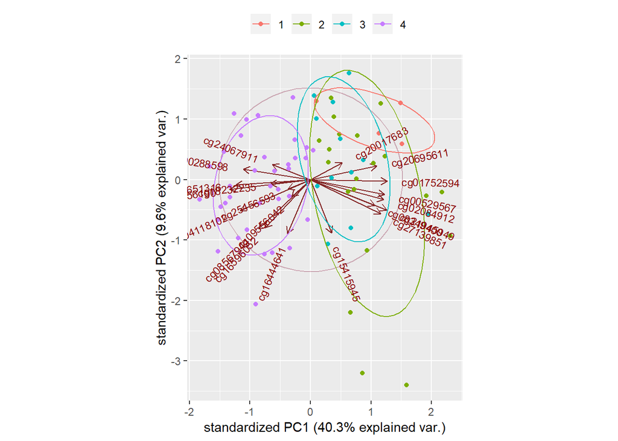

```r
ggbiplot(features.pca, groups=features2$pma_levels, circle=TRUE, ellipse=TRUE) +
    scale_color_discrete(name = '') +
    theme(legend.direction = 'horizontal', legend.position = 'top')
```

## Limitations: First, a number of the PMA values were assumed to be MCAR and were imputed. This may have impacted the model and over-emphazised the perfect prediction of gestational age for infants > 38 weeks. Not all of the DMRs included int the SVM had a statistically significant p-value, and this could be addressed by re-running the SVM using only the CpGs that were included in the PCA. Lastly, this methylation data was initally normalized using a function specifically to account for baseline differences between groups. If the more traditional quantile normalization had been used, the prediction model may be been more accurate.

### Conclusions

DMRs are strongly predictive of gestational age using a SVM. This may suggest that these DMRs found in comparisons of term and preterm infants may be largely the result of different stages of development, rather than of any potential pathology. This model and hypothesis will need to be validated using additional datasets as well as other machine learning algorithms (e.g., random forests).

### References

1. Godfrey, Keith M., Karen A. Lillycrop, Graham C. Burdge, Peter D. Gluckman, and Mark A. Hanson. “Epigenetic mechanisms and the mismatch concept of the developmental origins of health and disease.” Pediatric research 61, no. 5 Part 2 (2007): 5R.
2. Yamada, L., and S. Chong. “Epigenetic studies in developmental origins of health and disease: pitfalls and key considerations for study design and interpretation.” Journal of developmental origins of health and disease 8, no. 1 (2017): 30-43.
3. Weaver, Ian CG, Nadia Cervoni, Frances A. Champagne, Ana C. D’Alessio, Shakti Sharma, Jonathan R. Seckl, Sergiy Dymov, Moshe Szyf, and Michael J. Meaney. “Epigenetic programming by maternal behavior.” Nature neuroscience 7, no. 8 (2004): 847.
4. Bind, Marie-Abele, Johanna Lepeule, Antonella Zanobetti, Antonio Gasparrini, Andrea A. Baccarelli, Brent A. Coull, Letizia Tarantini, Pantel S. Vokonas, Petros Koutrakis, and Joel Schwartz. “Air pollution and gene-specific methylation in the Normative Aging Study: association, effect modification, and mediation analysis.” Epigenetics 9, no. 3 (2014): 448-458.
5. Kundakovic, Marija, and Ivana Jaric. “The epigenetic link between prenatal adverse environments and neurodevelopmental disorders.” Genes 8, no. 3 (2017): 104.
6. O’donnell, K., T. G. O’connor, and V. Glover. “Prenatal stress and neurodevelopment of the child: focus on the HPA axis and role of the placenta.” Developmental neuroscience 31, no. 4 (2009): 285-292.
7. Welberg, Leonie AM, and Jonathan R. Seckl. “Prenatal stress, glucocorticoids and the programming of the brain.” Journal of neuroendocrinology 13, no. 2 (2001): 113-128.
8. Goldberg, Aaron D., C. David Allis, and Emily Bernstein. “Epigenetics: a landscape takes shape.” Cell 128, no. 4 (2007): 635-638.
9. Heijmans, Bastiaan T., Elmar W. Tobi, Aryeh D. Stein, Hein Putter, Gerard J. Blauw, Ezra S. Susser, P. Eline Slagboom, and L. H. Lumey. “Persistent epigenetic differences associated with prenatal exposure to famine in humans.” Proceedings of the National Academy of Sciences 105, no. 44 (2008): 17046-17049.
10. Montirosso, Rosario, and Livio Provenzi. “Implications of epigenetics and stress regulation on research and developmental care of preterm infants.” Journal of Obstetric, Gynecologic & Neonatal Nursing 44, no. 2 (2015): 174-182.
11. Burris, Heather H., Andrea A. Baccarelli, Robert O. Wright, and Rosalind J. Wright. “Epigenetics: linking social and environmental exposures to preterm birth.” Pediatric research 79, no. 1-2 (2015): 136.
12. Chen, Hsinchun. “Machine learning for information retrieval: neural networks, symbolic learning, and genetic algorithms.” Journal of the American society for Information Science 46, no. 3 (1995): 194-216.
13. Joubert, Bonnie R., Siri E. Håberg, Roy M. Nilsen, Xuting Wang, Stein E. Vollset, Susan K. Murphy, Zhiqing Huang et al. “450K epigenome-wide scan identifies differential DNA methylation in newborns related to maternal smoking during pregnancy.” Environmental health perspectives 120, no. 10 (2012): 1425.
14. Libbrecht, Maxwell W., and William Stafford Noble. “Machine learning applications in genetics and genomics.” Nature Reviews Genetics 16, no. 6 (2015): 321.
15. Geiman, Theresa M., and Kathrin Muegge. “DNA methylation in early development.” Molecular Reproduction and Development: Incorporating Gamete Research 77, no. 2 (2010): 105-113.
16. Borgel, Julie, Sylvain Guibert, Yufeng Li, Hatsune Chiba, Dirk Schübeler, Hiroyuki Sasaki, Thierry Forné, and Michael Weber. “Targets and dynamics of promoter DNA methylation during early mouse development.” Nature genetics 42, no. 12 (2010): 1093.
17. Jean-Philippe Fortin, Aurélie Labbe, Mathieu Lemire, Brent W Zanke, Thomas J Hudson, Elana J Fertig, Celia MT Greenwood, and Kasper D Hansen. 2014. “Functional normalization of 450k methylation array data improves replication in large cancer studies.” Genome Biology 15 (11): 503. doi:10.1186/s13059-014-0503-2.
18. Aryee MJ, Jaffe AE, Corrada-Bravo H, Ladd-Acosta C, Feinberg AP, Hansen KD, Irizarry RA (2014). “Minfi: A flexible and comprehensive Bioconductor package for the analysis of Infinium DNA Methylation microarrays.” Bioinformatics, 30(10), 1363–1369. doi: 10.1093/bioinformatics/btu049.
19. Landis JR, Koch GG (1977) The measurement of observer agreement for categorical data. Biometrics, 33: 159-174.